# ejercicios05

Valentina Paz Campos Olguín

2023-06-22

# Ejercicio 05

## Utilizando una de las distribuciones de probabilidad con las que trabajó en el Ejercicio 3, ver la planilla.

En este caso, se utiliza la distribución Student.

$$X \sim t(\nu)$$

**Función de densidad**

$$\frac{\Gamma(\frac{(\nu + 1)}{2})}{\sqrt{\nu\pi} \Gamma(\frac{\nu}{2})}
(1+\frac{x²}{\nu})^{-\frac{(\nu+1)}{2}}$$

**Productoria**

$$L(\nu; x_{1}, ..., x_{n}) = \prod_{j=1}^{n}f(x_{j}, \nu) =
\prod_{j=1}^{n}\frac{\Gamma(\frac{(\nu + 1)}{2})}{\sqrt{\nu\pi}
\Gamma(\frac{\nu}{2})} (1+\frac{x_{j}²}{\nu})^{-\frac{(\nu+1)}{2}}$$

### 1. Cree un ejemplo de estimación de máxima verosimilitud para **una de las distribuciones de probabilidad seleccionadas. Vea un ejemplo en el siguiente link: ejemplo.**

#### a. Defina una semilla para el generador de números aleatorios.

```r
set.seed(123)
```

#### b. Cree una muestra aleatoria utilizando la función con prefijo “r” con parámetros fijos $\theta_{0}$.

```r
#Tamaño de la muestra
N = 100

#Parámetro verdadero de localización
beta = 2

#Parámetro verdadero de grados de libertad
sigma_2 = 5

#Se genera muestra aleatoria
DT <- data.table(X = rt(N, df = 5, ncp = 2),
                 U = rnorm(N, 0, sqrt(sigma_2))) %>%
  .[, Y := beta*X + U]
```

#### c. Implemente y grafique la función *log(L(*$\theta$*))*.

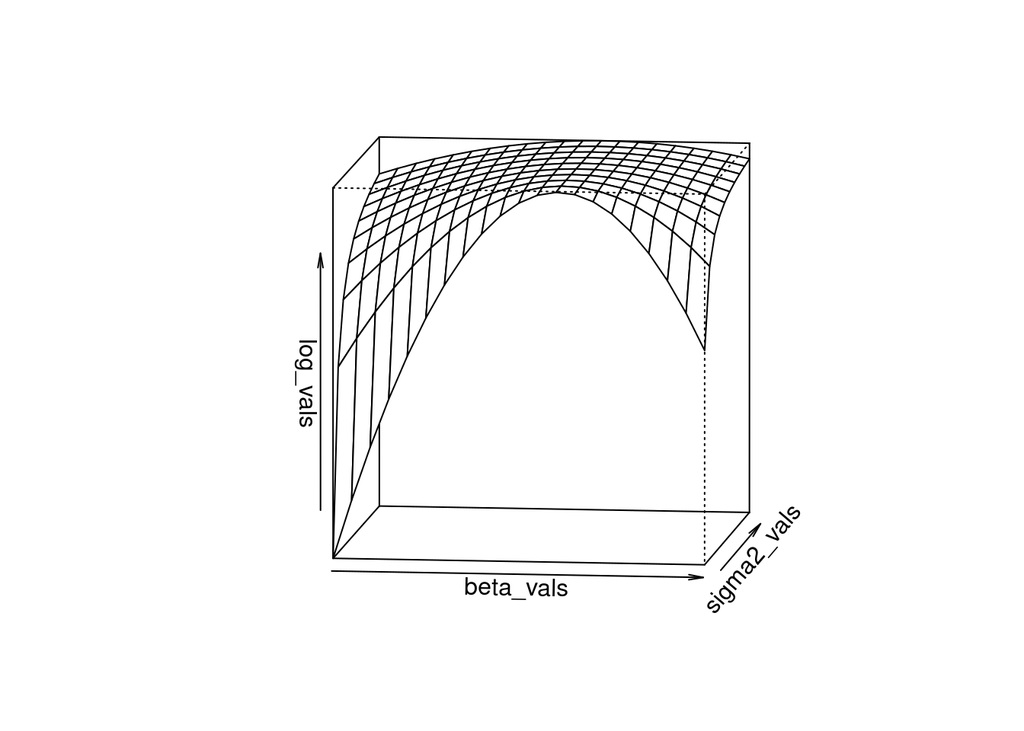

```r
#Se realiza la función de verosimilitud
log_likelihood <- function(theta, Y, X){
  X <- as.matrix(X); Y <- as.matrix(Y);
  N <- nrow(X)
  beta <- theta[1]
  sigma_2 <- theta[2]
  e <- Y - beta*X
  loglik <- -0.5*N*log(2*pi) - 0.5*N*log(sigma_2) - ((t(e) %*% e)/(2*sigma_2))
  return(-loglik)
}

#Se grafica la función de verosimilitud
log_like_graph <- function(beta, sigma_2){
  X <- as.matrix(DT$X); Y <- as.matrix(DT$Y);
  N <- nrow(X)
  e <- Y - beta*X
  loglik <- 0.5*N*log(2*pi) - 0.5*N*log(sigma_2) - ((t(e) %*% e)/(2*sigma_2))
  return(loglik)
}

log_like_graph <- Vectorize(log_like_graph)

#Crear matriz de valores para graficar beta y sigma
beta_vals <- seq(-10, 10, by = 1)
sigma2_vals <- seq(1, 10, by = 1)
log_vals <- outer(beta_vals, sigma2_vals, log_like_graph)

persp(beta_vals, sigma2_vals, log_vals, theta = 7, phi = 8, r = 500)
```

```r
MLE_estimates <- optim(fn=log_likelihood,     # Función de verosimilitud
                       par=c(1,1),            # Estimación inicial
                       lower = c(-Inf, -Inf),     # Límite inferior de los parámetros
                       upper = c(Inf, Inf),      # Límite superior de los parámetros
                       hessian=TRUE,          # Devuelve el Hessiano
                       method = "L-BFGS-B",   # Entradas personalizadas
                       Y = DT$Y,
                       X = DT$X)

# Examinar estimaciones
MLE_par <- MLE_estimates$par
MLE_SE <- sqrt(diag(solve(MLE_estimates$hessian)))
MLE <- data.table(param = c("beta", "sigma_2"),
                  estimates = MLE_par,
                  sd = MLE_SE)

MLE
```

```
##      param estimates         sd
## 1:    beta  2.131293 0.07952491
## 2: sigma_2  4.946088 0.69948290
```

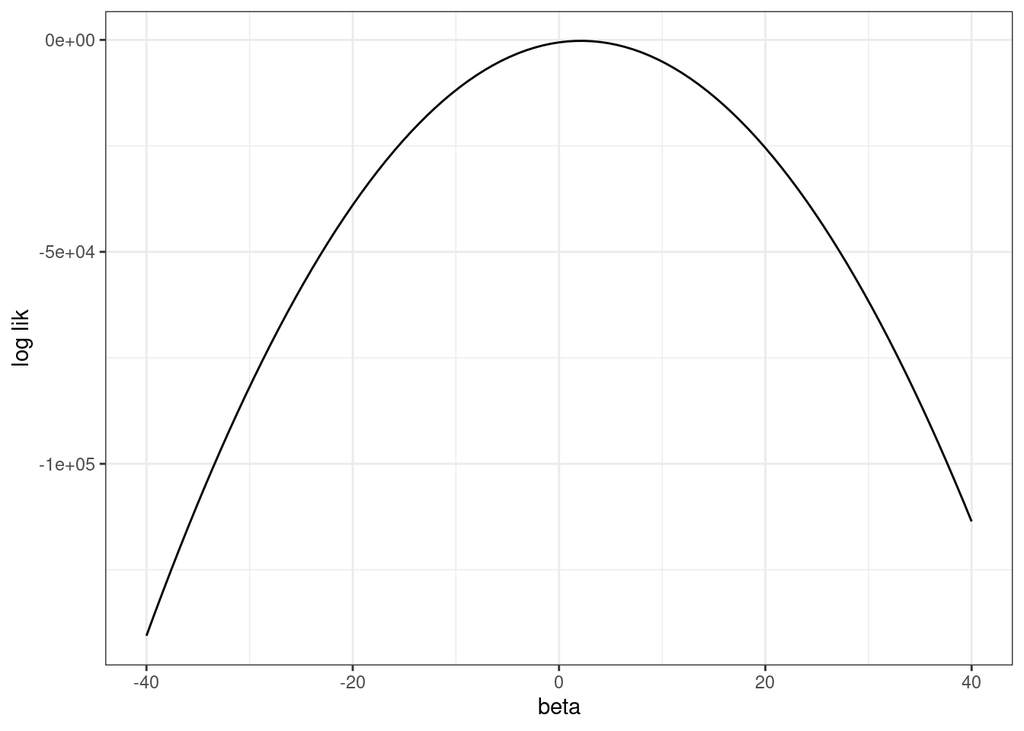

```r
log_like_graph_beta <- function(beta){
  sigma_2 = MLE_par[2]
  X = as.matrix(DT$X)
  Y = as.matrix(DT$Y)
  N = nrow(X)
  e = Y - beta*X
  loglik <- -0.5*N*log(2*pi) - 0.5*N*log(sigma_2) - ((t(e) %*% e)/(2*sigma_2))
  return(loglik)
}

log_like_graph_sigma2 <- function(sigma_2){
  beta = MLE_par[1]
  X = as.matrix(DT$X)
  Y = as.matrix(DT$Y)
  N = nrow(X)
  e = Y - beta*X
  loglik <- -0.5*N*log(2*pi) - 0.5*N*log(sigma_2) - ((t(e) %*% e)/(2*sigma_2))
  return(loglik)
}

#Se vectoriza
log_like_graph_beta <- Vectorize(log_like_graph_beta)
log_like_graph_sigma2 <- Vectorize(log_like_graph_sigma2)

#Gráfico
beta <- ggplot(data = data.frame(beta = 0), mapping = aes(beta = beta)) +
  stat_function(fun = log_like_graph_beta) + xlim(-40, 40) + theme_bw() +
  xlab("beta") + ylab("log lik")

sigma2 <- ggplot(data = data.frame(sigma2 = 0), mapping = aes(sigma2 = sigma2)) +
  stat_function(fun = log_like_graph_sigma2) + xlim(1, 20) + theme_bw() +
  xlab("sigma2") + ylab("log lik")

beta
```

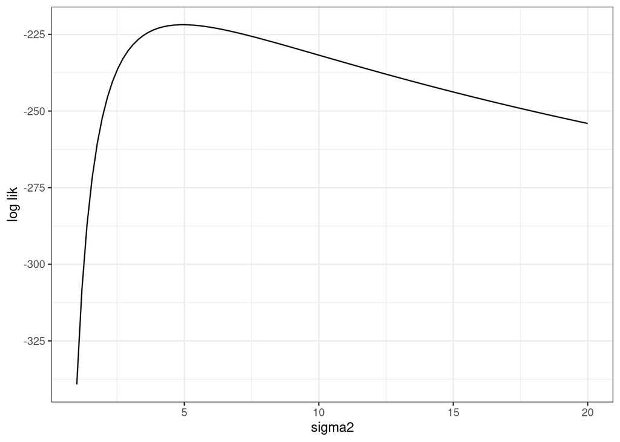

```r
sigma2
```

#### d. Utilice la función *optim()* de R para minimizar *log(L(*$\theta$))*.*

```r
example = rt(N, 5, 2)
parametros_iniciales <- c(0, 1)
estimacion <- optim(fn = log_likelihood, par = parametros_iniciales,
                    hessian = TRUE, method = "BFGS", Y = DT$Y, X = DT$X)
```

#### e. Compare los parámetros estimados $\theta$ con los parámetros con los que generó la muestra $\theta_{0}$ y concluya.

```r
ncp = estimacion$par[2]
df = estimacion$par[1]

paste(5, "es el valor inicial.", ncp, "es el valor aproximado.")
```

```
## [1] "5 es el valor inicial. 4.94608343391759 es el valor aproximado."
```

```r
paste(2, "es el valor inicial.", df, "es el valor aproximado.")
```

```
## [1] "2 es el valor inicial. 2.13129224078133 es el valor aproximado."
```

```r
error_ncp = ((5 - ncp)/5)*100
error_df = ((df - 2)/2)*100

paste("El error de ncp es: ", error_ncp, "%")
```

```
## [1] "El error de ncp es:  1.07833132164826 %"
```

```r
paste("El error de df es: ", error_df, "%")
```

```
## [1] "El error de df es:  6.56461203906651 %"
```

Se puede observar que los parámetros estimados y los parámetros verdaderos tienen una gran similitud, siendo el error del parámetro de los grados de libertad (ncp) un 1.08% y del parámetro de localización (df) es un 6.56%.